# Module 3 - Panel (Answer Key)

ECON 526/593E

# Panel Data Methods

**Click for Submission Instructions & Data**

Prepare your answers in R Markdown. Your submission should contain the exact same headings shown below along with your text and graphs, where appropriate, addressing all questions. When you knit your R Markdown script, use the following file naming convention for the html and Rmd documents you generate: lastname_module_N_homework.html (.Rmd) (replace "lastname" with your last name and "N" with the module number). Email your documents as attachments to ajc0056@mix.wvu.edu with the subject line "ECON 593 lastname Homework Module N". You can download the data for this module here. It will specify when/where packages are needed.

Sport franchises are firms that make decisions to maximize profits. One way to increase profits is to more sell tickets, which generates more revenue. Profit maximizing sports franchises would be interested in the relationship between ticket sales and team success. In other words, do winning teams sell more tickets? The relationship between winning and ticket sales is not clear *a priori*. On one hand, fans could be more likely to buy a ticket to see a successful team play, suggesting a positive relationship. On the other hand, season ticket holders might represent the majority of ticket buyers, in which case team success would have a weak or no relationship to ticket sales. NBA teams would have an interest in the causal impact of team success on ticket sales, since that would help them to decide whether or not they should improve team quality to win more games and earn higher profits.

Note that the relationship between team success and ticket sales may reflect unobserved heterogeneity based on unique characteristics of the fans in cities where teams play, and also in terms of unobservable characteristics unique to different seasons. Residents of some cities might strictly prefer winning teams, making the win/attendance relationship stronger there; residents of other cities might be more tolerant of losing teams (looking at you Pittsburgh Pirates' fans) making the wins/attendance relationship weaker. Assume these factors never change within a city over time. Unobservable season specific factors include things like changes in the popularity of other entertainment options that makes attending NBA games less attractive, perhaps a string of blockbuster movies released in a specific year, or macroeconomic business cycle effects like recessions or expansions. These factors affect all cities with NBA teams.

The sample period contains several unusual seasons that need to be taken into account in the analysis. Data from the 2019/20 season should be considered incomplete due to the impact of the COVID-19 pandemic on attendance. The 1998/99 and 2011/12 seasons contained fewer games than usual because of work stoppages (in particular "lockouts" where team owners prevented players from working) that resulted in game cancellations that were not made up. How might these seasons affect the relationship between wins and attendance? Total attendance in shortened seasons would be lower. Shorter seasons could reduce average attendance if fan's became annoyed by the interruption in play and decided not to attend.

## Question 1

Summarize the main research question in this homework, the application analyzed and why this causal inference approach is appropriate for this research question. (**2 Points**)

## Question 2

Read in the data `nba_teams.csv`.

Describe the data analyzed, including general structure of the data set, and the variables included in the data set. Discuss why these data might be appropriate for this causal inference method. Generate summary statistics for all of the main variables used in the analysis using the `stargazer` package.

Before starting the analysis, drop all observations from the 2019/20 season from the sample. Next, Create a variable called `lockout` that is equal to `1` if the season is equal to 1999 or 2012 and `0` otherwise. Divide all attendance variable observations by 1,000 to make the parameter estimates look nicer (this has no effect on the results, except for the location of the decimal place on the parameter estimate on the attendance variable). Create a variable called `attendance_pergame` which is attendance divided by the number of games played in each season. (**2 points**)

```r
library("stargazer")
nba <- read.csv("nba_teams.csv", stringsAsFactors = FALSE)

#select rows where year < 2020, only keep these
nba <- nba[nba$year < 2020,]

#divide attendance by 1000
nba$attendance <- nba$attendance / 1000

#if nba$year is equal to either 1999 or 2012, 1 otherwise 0
nba$lockout <- ifelse(nba$year %in% c(1999, 2012), 1, 0)
nba$attendance_pergame <- nba$attendance/nba$games

stargazer(nba, type = "text")
```

```
##
## ===========================================================================
## Statistic           N    Mean    St. Dev.   Min   Pctl(25) Pctl(75)   Max
## ---------------------------------------------------------------------------
## attendance         406  686.128  118.533  232.895 620.390  771.836  983.444
## year               406 2,005.000  8.377    1,991   1,998    2,012    2,019
## w                  406  41.268    13.227     9      31.2      52      73
## l                  406  39.071    13.320     9      27.2      49      71
## games              406  80.340    6.441     50       82       82      82
## lockout            406   0.069    0.254      0       0        0        1
## attendance_pergame 406   8.539    1.305    2.840   7.685    9.482   11.993
## ---------------------------------------------------------------------------
```

## Question 3

Describe the causal inference method used in this homework. Discuss the assumptions underlying the causal inference method used. Include a discussion of threats to validity of the results in terms of causal inference if appropriate. (**2 points**)

## Question 4

Visualize the data. (**2 points**)

Generate a histogram for the attendance variable. Generate a tabulation plot of wins (hint[^1]). Discuss what information these graphs convey in terms of behavior of the variables as well as similarities and differences (advantages and disadvantages) in the two formats output/display.

Generate a scatter plots of attendance (y axis) vs wins (x axis). Highlight the Chicago Bulls ("CHI") in one color and all other teams in a different color. Redo this scatterplot, but instead of highlighting the Bulls, highlight the year 1999 in one color, 2012 in a second color, and all other seasons in a third color. Also, make the symbol for observations in 1999 a solid square, 2012 a solid circle and all other observations an open triangle. Make a *third* scatter plot of attendance per game vs winning percentage (wins / game, name this variable `win_percent`). For this plot, follow the same sort of highlighting as in the previous plot. For each figure, create a legend in the lower right corner that tells what the colors and shapes mean in their respective plots (hint[^2], hint[^3]). Remember to label the axes.

Discuss what you learn from these scatter plots. What pattern emerges from the red dots for the Bulls? How does this relate to unobserved heterogeneity across cities? What impact did the 1999 NBA lockout have on the wins/attendance relationship on an aggregate level? On a per-game level? Was the 1999 lockout different than the 2012 lockout in terms of the impact on attendance?

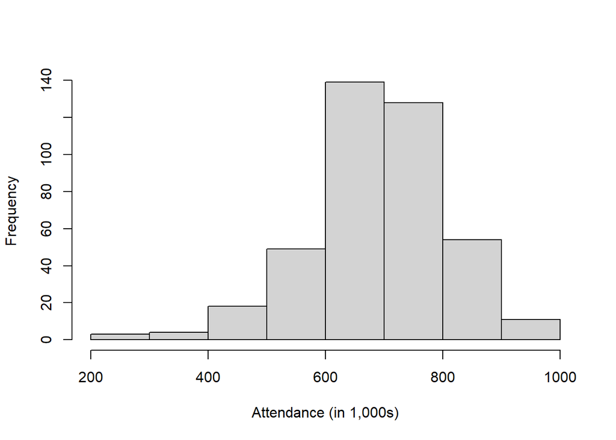

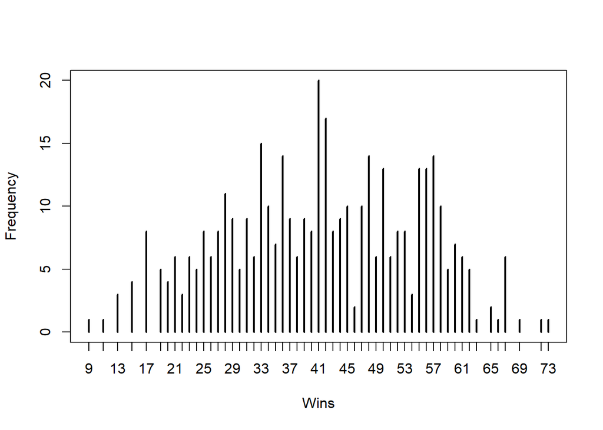

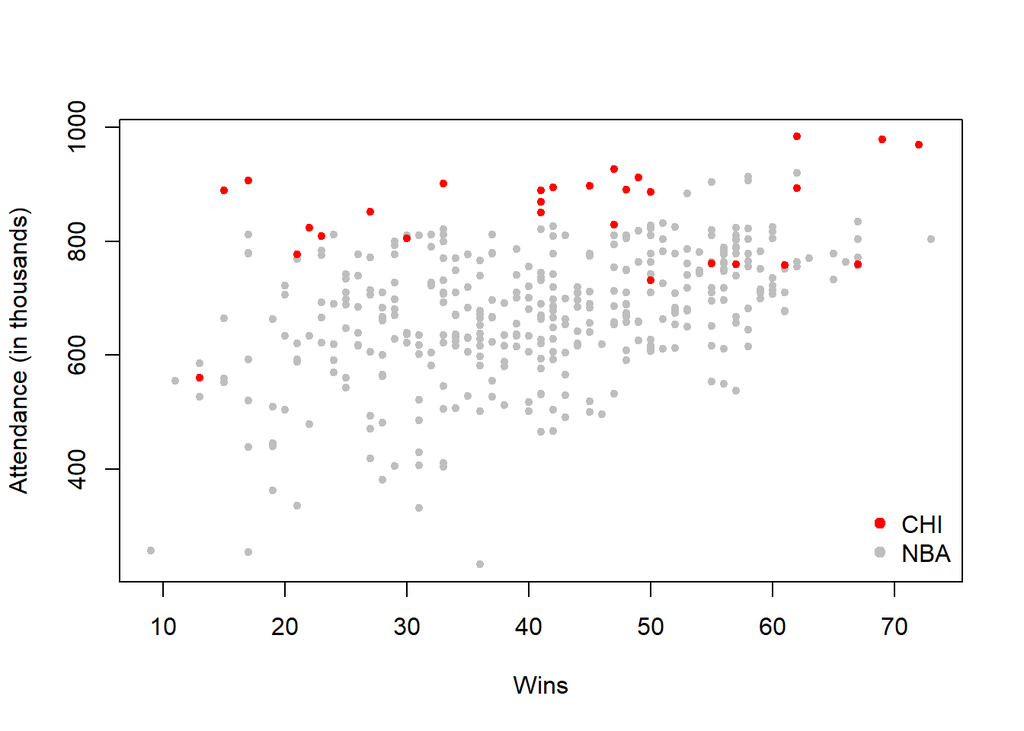

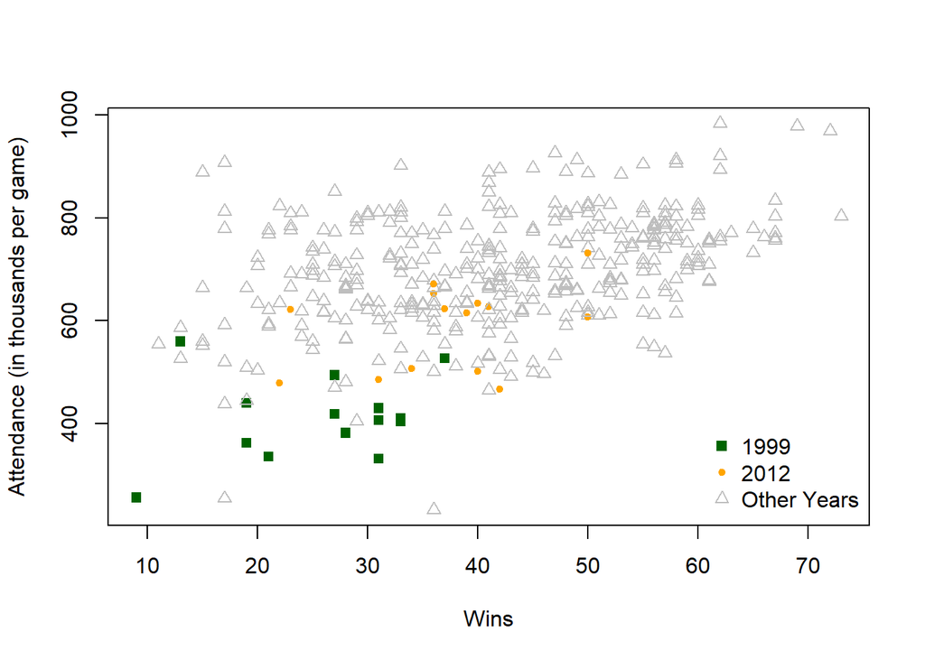

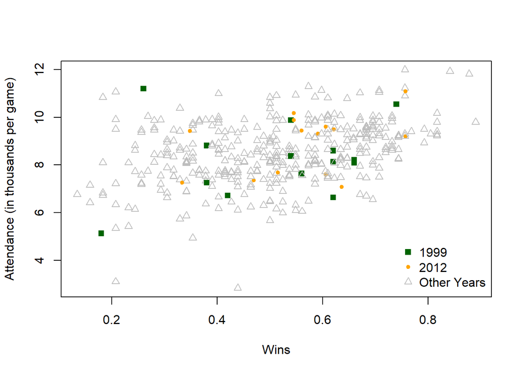

```r
#histogram bins continuous data
hist(nba$attendance, xlab = "Attendance (in 1,000s)", ylab = "Frequency", main = "")
#table counts up discrete observations
plot(table(nba$w), ylab = "Frequency", xlab = "Wins", main = "")


plot(nba$w, nba$attendance,
     col = ifelse(nba$team == "CHI", "red", "grey"),
     pch = 20, main = "",
     xlab = "Wins", ylab = "Attendance (in thousands)")
legend(legend = c("CHI", "NBA"),
       pch = 19, col = c("red", "grey"),
       "bottomright", bty = "n")

plot(nba$w, nba$attendance,
     #if 1999, dark green, if 2012, orange, otherwise grey
     col = ifelse(nba$year == 1999, "dark green", ifelse(nba$year == 2012, "orange", "grey")),
     pch = ifelse(nba$year == 1999, 15, ifelse(nba$year == 2012, 20, 2)),
     main = "",
     xlab = "Wins", ylab = "Attendance (in thousands per game)")
legend(legend = c("1999", "2012", "Other Years"),
       pch = c(15, 20, 2), col = c("dark green", "orange", "grey"),
       "bottomright", bty = "n")

plot(nba$w/nba$games, nba$attendance/nba$games,
     col = ifelse(nba$year == 1999, "dark green", ifelse(nba$year == 2012, "orange", "grey")),
     pch = ifelse(nba$year == 1999, 15, ifelse(nba$year == 2012, 20, 2)),
     main = "",
     xlab = "Wins", ylab = "Attendance (in thousands per game)")
legend(legend = c("1999", "2012", "Other Years"),
       pch = c(15, 20, 2), col = c("dark green", "orange", "grey"),
       "bottomright", bty = "n")
```

## Question 5

Estimate the following panel data regression model. Make sure that you follow the guidelines for reproducible research (as discussed in "Making a Pie") in your code and analysis. (**2 points**)

Estimate a regression model that explains variation in attendance using the number of wins as an explanatory variable. Estimate a second regression model that controls for both wins and the each individual season in the sample (remember to convert season to a `factor` variable). Estimate a third regression model that controls for wins and time-invariant team specific effects. Estimate a fourth regression model including wins, season-specific effects and team-specific effects.

Use `stargazer` to display your results (hint[^4], hint[^5]). When running regressions with fixed effects, do not display the `Constant` in the output. Estimating a model with both an intercept and fixed effects creates perfect multicollinearity. In other words, the regression cannot estimate each fixed effect parameter *and* the intercept, so the intercept loses it's interpretation.

```r
reg1 <- lm(attendance ~ w, data = nba)
reg2 <- lm(attendance ~ w + as.factor(year), data = nba)
reg3 <- lm(attendance ~ w + as.factor(team), data = nba)
reg4 <- lm(attendance ~ w + as.factor(team) + as.factor(year), data = nba)
stargazer(reg1, reg2, reg3, reg4, type = "text",
          omit = c("factor", "Constant"), #hides fixed effects
          omit.stat = c("ser", "f"), #hides f-stat and resid. st. error
          add.lines = list(c("Team FE", "No", "No", "Yes", "Yes"),
                           c("Year FE", "No", "Yes", "No", "Yes")))
```

```
##
## ================================================
##                      Dependent variable:
##              -----------------------------------
##                          attendance
##                (1)      (2)      (3)      (4)
## ------------------------------------------------
## w            3.800*** 2.971*** 3.580*** 2.578***
##              (0.404)  (0.361)  (0.349)  (0.265)
##
## ------------------------------------------------
## Team FE         No       No      Yes      Yes
## Year FE         No      Yes       No      Yes
## Observations   406      406      406      406
## R2            0.180    0.432    0.493    0.751
## Adjusted R2   0.178    0.388    0.474    0.723
## ================================================
## Note:                *p<0.1; **p<0.05; ***p<0.01
```

NBA teams cannot do much about occasional lockout seasons with less games played. Therefore, they may care more about per-game attendance rather than total attendance. Do a t-test to see if per-game attendance in lockout seasons is statistically different from per-game attendance in non-lockout seasons.

```r
t.test((nba$attendance_pergame)[nba$lockout == 1],
       (nba$attendance_pergame)[nba$lockout == 0])
```

```
##
##  Welch Two Sample t-test
##
## data:  (nba$attendance_pergame)[nba$lockout == 1] and (nba$attendance_pergame)[nba$lockout == 0]
## t = 0.10542, df = 30.273, p-value = 0.9167
## alternative hypothesis: true difference in means is not equal to 0
## 95 percent confidence interval:
##  -0.5464763  0.6059877
## sample estimates:
## mean of x mean of y
##  8.566293  8.536537
```

Re-estimate all regression models using attendance per game as the dependent variable and winning % (wins / games, name the variable `win_percent`) as the independent variable. Use `stargazer` to display your results.

```r
nba$win_percent <- nba$w / nba$games
reg1 <- lm(attendance_pergame ~ win_percent, data = nba)
reg2 <- lm(attendance_pergame ~ win_percent + as.factor(year), data = nba)
reg3 <- lm(attendance_pergame ~ win_percent + as.factor(team), data = nba)
reg4 <- lm(attendance_pergame ~ win_percent + as.factor(team) + as.factor(year), data = nba)
stargazer(reg1, reg2, reg3, reg4, type = "text",
          omit = c("factor", "Constant"),
          omit.stat = c("ser", "f"),
          add.lines = list(c("Team FE", "No", "No", "Yes", "Yes"),
                           c("Year FE", "No", "Yes", "No", "Yes")))
```

```
##
## ================================================
##                      Dependent variable:
##              -----------------------------------
##                      attendance_pergame
##                (1)      (2)      (3)      (4)
## ------------------------------------------------
## win_percent  2.991*** 2.966*** 2.615*** 2.577***
##              (0.379)  (0.365)  (0.303)  (0.268)
##
## ------------------------------------------------
## Team FE         No       No      Yes      Yes
## Year FE         No      Yes       No      Yes
## Observations   406      406      406      406
## R2            0.134    0.266    0.547    0.679
## Adjusted R2   0.131    0.209    0.530    0.642
## ================================================
## Note:                *p<0.1; **p<0.05; ***p<0.01
```

## Question 6

Discuss the results you generated. What is the interpretation of the causal parameter of interest? Place the causal effect in the context of the data (in particular, how big or small is the causal parameter of interest relative to the dependent variable). (**2 points**)

Discuss the sensitivity of the parameter estimates within, and across, both sets of regression models. Is one dependent variable more sensitive to the inclusion of fixed effects than the other? Why or why not? What was the result of the t-test?

## Question 7

Compare your results and this application to the example in *The Mixtape* chapter for this causal inference method. Is this application better or worse than the one in the chapter? How does this application, and these results, differ? For example, strength of assumptions, effect size, etc. (**2 points**)

## Question 8

Do you believe the result is credibly causal? Are the sign and magnitude plausible? (**2 points**)

If you worked for an NBA team trying to maximize their profits, what would you suggest to them after presenting these results? Is winning more games a profit maximizing policy?

[^1]: Plot the function `table()`.
[^2]: Check out [this resource](http://www.sthda.com/english/wiki/add-legends-to-plots-in-r-software-the-easiest-way).
[^3]: Grey is a good option for a non-highlighted color.
[^4]: Pass the argument `omit = c("factor")` to stargazer. Otherwise, the output will be very long. Make sure to continue omitting the f-stat and residual standard error like in previous homeworks.
[^5]: Use the `add.lines` option to tell which column contains which fixed effects.